# HW3_Udayakumar_Balaji

Name: Course: BUDT704 Section: <0503> Date: <10/06/2023>

## Importing Numpy Library

```python
import numpy as np
```

## Loading the amount pledged (in U.S. dollars) data across all projects

- We are loading data from'HW3_kickstarter.csv'.
- The `np.loadtxt` function is used to load the data from the file.
- `skiprows=1` skips the header row when reading the data.
- `usecols=11` specifies that we are fetching the data from the 11th column (the index starts from 0).
- `delimiter=','` indicates that the data in the CSV file is separated by commas.

```python
# Loading the amount pledged (in U.S. dollars) data
amount_pledged = np.loadtxt('HW3_kickstarter.csv', skiprows=1, usecols = 11, delimiter=',')
```

## Displaying descriptive statistics

- We calculate various statistics related to the amount pledged (in U.S. dollars) for Kickstarter projects.
- The total number of projects is calculated using `len(amount_pledged)`.
- Minimum, maximum, mean, median, and standard deviation for the amount pledged are calculated using NumPy functions.
- The percentage of projects that earned total pledges of at least $2,500 is calculated and printed.
- Finally, the results are being printed.

```python
# Calculating total number of projects

total_no_of_projects = len(amount_pledged)
total_no_of_projects

# Calculating min, max, mean, median, and standard deviation for amount pledged in US dollars

min_amt_pledged = np.min(amount_pledged)
max_amt_pledged = np.max(amount_pledged)
mean_amt_pledged = np.mean(amount_pledged)
median_amt_pledged = np.median(amount_pledged)
std_dev_amt_pledged = np.std(amount_pledged)

# Calculating % of projects that earned total pledges of at least $2500.

pledge_limit = 2500
projects_above_limit = np.sum(amount_pledged >= pledge_limit)
percentage_above_limit = (projects_above_limit/total_no_of_projects) * 100

# Print results

print("--------Total number of projects----------")
print("\t\t",total_no_of_projects)
print("--------Amount pledged (in U.S. dollars): min, max, mean, median, and standard deviation----------")
print("\t\tMinimum:", min_amt_pledged)
print("\t\tMaximum:", "{:.2f}".format(max_amt_pledged))
print("\t\tMean:", "{:.2f}".format(mean_amt_pledged))
print("\t\tMedian:", "{:.2f}".format(median_amt_pledged))
print("\t\tStandard Deviation:", "{:.2f}".format(std_dev_amt_pledged))
print("--------Percentage of projects that earned total pledges of at least $2,500.----------")
print("\t\t", "{:.2f}".format(percentage_above_limit))
```

```
--------Total number of projects----------
		 4184
--------Amount pledged (in U.S. dollars): min, max, mean, median, and standard deviation----------
		Minimum: 0.0
		Maximum: 111111.77
		Mean: 1242.12
		Median: 90.00
		Standard Deviation: 5177.93
--------Percentage of projects that earned total pledges of at least $2,500.----------
		 10.59
```

## Load the project categories data

- We are loading data from 'HW3_kickstarter.csv'.
- The `np.loadtxt` function is used to load the data from the file.
- `skiprows=1` skips the header row when reading the data.
- `usecols=12` specifies that we are fetching the data from the 12th column (the index starts from 0).
- `delimiter=','` indicates that the data in the CSV file is separated by commas.

```python
## Loading the project categories data
project_category = np.loadtxt('HW3_kickstarter.csv', skiprows=1, usecols = 12, delimiter=',', dtype = str)
project_category
```

```
array(['Conceptual Art', 'Conceptual Art', 'Conceptual Art', ...,
       'Painting', 'Painting', 'Painting'], dtype='<U14')
```

## Calculating frequency of each category

- An empty dictionary called `frequency_of_category` is created to determine the frequency of each category.
- A loop iterates through the `project_category` array iterating through the categories of projects.
- Inside the loop, we check if a category is already in the `frequency_of_category` dictionary. If it is, we increment the count for that category; otherwise, we initialize the count to 1.
- Finally, we print the frequency of each category along with the category name using a loop.

```python
# Created an empty dict to determine the frequency of each category
frequency_of_category = {}

# Code Logic to count the frequency of each category
for category in project_category:
    if category in frequency_of_category:
        frequency_of_category[category]+=1
    else:
        frequency_of_category[category]=1

# Printing frequency of each category
for category,count in frequency_of_category.items():
    print(f'{category}: {count}')
```

```
Conceptual Art: 879
Digital Art: 1054
Illustration: 461
Painting: 1586
Ceramics: 204
```

## Calculating the proportion (percentage) of observations for each category

- A dictionary comprehension is used to calculate the proportion (percentage) of each category in the dataset.
- `proportion_of_category` is created as a dictionary where each category is the key, and the corresponding proportion (percentage) is calculated using the formula `(count / total_no_of_projects) * 100`.
- A loop is used to print the category and its corresponding percentage from the `proportion_of_category` dictionary.

```python
# Using a dictionary comprehension to calculate the proportion(percentage) of categories
proportion_of_category = {category:(count/total_no_of_projects)*100 for category,count in frequency_of_category.items()}

# Printing the proportion(percentage) of categories
for category,category_percentage in proportion_of_category.items():
    print(f'{category}: {category_percentage}')
```

```
Conceptual Art: 21.008604206500955
Digital Art: 25.191204588910132
Illustration: 11.018164435946463
Painting: 37.90630975143404
Ceramics: 4.875717017208412
```

## Creating a bar chart showing a title, the categories, and percentages

- The `matplotlib.pyplot` library is imported as `plt`.
- The `seaborn` library is imported as `sns`.

```python
import matplotlib.pyplot as plt
import seaborn as sns
```

## Bar chart using matplotlib library

- A bar chart is created using Matplotlib to visualize the proportion (percentage) of each project category.
- `x` contains the project category names obtained from the keys of the `proportion_of_category` dictionary.
- `y` contains the corresponding proportions (percentages) obtained from the values of the `proportion_of_category` dictionary.
- The figure size, title, and labels for the x and y axes are set.
- A bar plot is created with the `plt.bar` function, and the bars are stored in the `bars` variable.
- For each bar, percentage labels are added on top using `plt.annotate` to display the percentage value for each category.
- The `plt.xticks` function is used to rotate the x-axis labels for better readability.
- Finally, the plot is displayed using `plt.show()`.

```
---------------  Bar graph using matplotlib library  -------------------
```

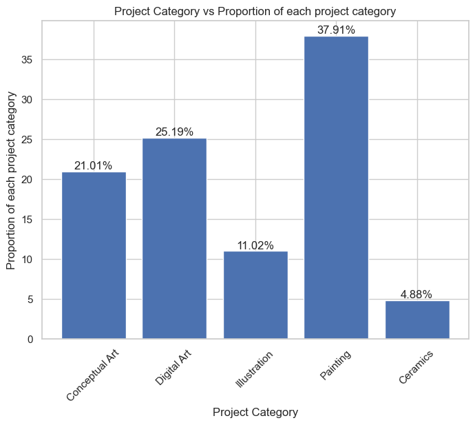

```python
# Displaying a bar chart showing a title, the categories, and percentages
x = proportion_of_category.keys()
y = proportion_of_category.values()
plt.figure(figsize=(8, 6))
plt.title('Project Category vs Proportion of each project category')
plt.xlabel('Project Category')
plt.ylabel('Proportion of each project category')
bars = plt.bar(x,y)
# Adding percentage labels on top of the bars
for bar in bars:
    height = bar.get_height()
    plt.annotate(f'{height:.2f}%', (bar.get_x() + bar.get_width() / 2, height),
                 ha='center', va='bottom', fontsize=12)
print('--------------- \033[1m Bar graph using matplotlib library \033[0m -------------------')

# Rotating horizontal axis labels by 45 degrees for better readability
plt.xticks(rotation=45)

# Show the plot
plt.show()
```

## Bar chart using seaborn library

- A bar graph using the Seaborn library is created to visualize the proportions of different project categories.
- Categories and their corresponding proportions are extracted from the `proportion_of_category` dictionary.
- A bar chart is created using `sns.barplot` with categories on the x-axis and proportions on the y-axis.
- Titles, labels, and rotations are added to the chart for better readability.
- Percentage labels are added on top of the bars to display the proportions.
- Finally, `plt.show()` is used to display the bar graph.

```
---------------  Bar graph using Seaborn library  -------------------
```

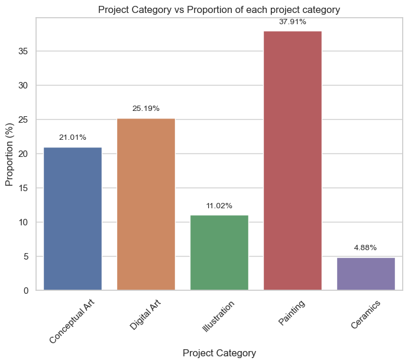

```python
# Displaying a bar chart showing a title, the categories, and percentages
print('--------------- \033[1m Bar graph using Seaborn library \033[0m -------------------')

#Data
categories = list(proportion_of_category.keys())
proportions = list(proportion_of_category.values())

# Creating a bar chart using Seaborn
plt.figure(figsize=(8, 6))
sns.set(style="whitegrid")  # Setting style
axes = sns.barplot(x=categories, y=proportions)
plt.title('Project Category vs Proportion of each project category')
plt.xlabel('Project Category')
plt.ylabel('Proportion (%)')
plt.xticks(rotation=45)

# Adding percentage labels on top of the bars
for category, proportion in zip(categories, proportions):
    axes.text(categories.index(category), proportion + 1, f'{proportion:.2f}%', ha='center', fontsize=10)

plt.show()
```

## Identify two inferences you can make about the various categories.

### Inference 1

- From the bar graph we can see that the category painting accounts for the most common proportion of art category among the lot. This indicates that a good number of submissions were of the category 'Painting' with a proportion of approximately 37.91%. This suggests that there is a significant interest and support for painting-related projects on the platform.

### Inference 2

- From the bar graph we can also see that the submission of projects is diverse with around five categories namely Conceptual Art, Digital Art, Illustration, Painting and Ceramics. This suggests that kickstarter attracts a wide range of projects from different categories to use their platform for fundraising objectives.

## Load the project states data

```python
## Loading the project states data
project_states = np.loadtxt('HW3_kickstarter.csv', skiprows=1, usecols = 4, delimiter=',', dtype = str)
project_states
```

```
array(['successful', 'successful', 'successful', ..., 'failed', 'failed',
       'failed'], dtype='<U10')
```

## Calculating the count of projects that were successful for each category

- An empty dictionary named `project_success` is created to store the count of successful projects by category.
- A loop iterates through the range of total number of projects.
- If a project is marked as 'successful' (based on `project_states[itr]`), it is categorized by its project category.
- The count of successful projects in each category is stored in the `project_success` dictionary.
- A subsequent loop is used to print the count of successful projects in each category, along with the total number of projects in that category (retrieved from the `frequency_of_category` dictionary).
- Finally, the total count of successful projects is calculated and stored in the variable `total_successful_projects`.

```python
project_success = {}
for itr in range(total_no_of_projects):
    if project_states[itr] == 'successful':
        if project_category[itr] in project_success:
            project_success[project_category[itr]]+=1
        else:
            project_success[project_category[itr]]=1

# Print count of successful projects
for category,success_count in project_success.items():
    print(f'Project Category - {category}: Success Counts - {success_count}: Total number of projects per category - {frequency_of_category[category]}')
```

```
Project Category - Conceptual Art: Success Counts - 322: Total number of projects per category - 879
Project Category - Digital Art: Success Counts - 286: Total number of projects per category - 1054
Project Category - Ceramics: Success Counts - 84: Total number of projects per category - 204
```

## Calculating the proportion (percentage) of projects that were successful in each category

```python
# Using a dictionary comprehension to calculate the proportion of project successes
proportion_of_success_projects_in_each_category = {category:(count/frequency_of_category[category])*100 for category,count in project_success.items()}

proportion_of_success_projects_in_each_category
```

```
{'Conceptual Art': 36.6325369738339,
 'Digital Art': 27.13472485768501,
 'Ceramics': 41.17647058823529}
```

## Bar Chart Inference

```
---------------  Bar graph using matplotlib library  -------------------
```

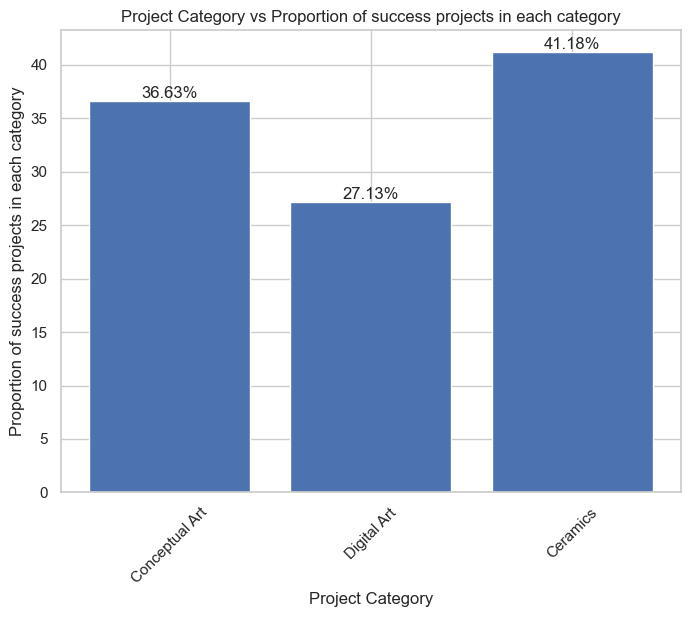

```python
# Displaying a bar chart showing a title, the categories, and percentages using matplotlib
x = proportion_of_success_projects_in_each_category.keys()
y = proportion_of_success_projects_in_each_category.values()
plt.figure(figsize=(8, 6))
plt.title('Project Category vs Proportion of success projects in each category')
plt.xlabel('Project Category')
plt.ylabel('Proportion of success projects in each category')
bars = plt.bar(x,y)

# Adding percentage labels on top of the bars
for bar in bars:
    height = bar.get_height()
    plt.annotate(f'{height:.2f}%', (bar.get_x() + bar.get_width() / 2, height),
                 ha='center', va='bottom', fontsize=12)
print('--------------- \033[1m Bar graph using matplotlib library \033[0m -------------------')

# Rotating horizontal axis labels by 45 degrees for better readability
plt.xticks(rotation=45)

# Showing the plot
plt.show()
```

```
---------------  Bar graph using seaborn library  -------------------
```

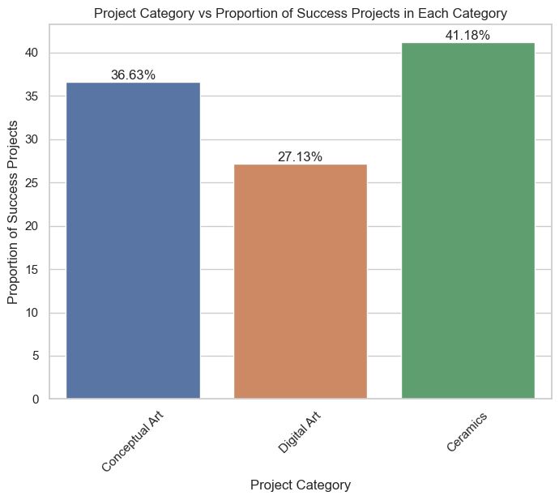

```python
# Displaying a bar chart showing a title, the categories, and percentages using seaborn
print('--------------- \033[1m Bar graph using seaborn library \033[0m -------------------')

# Data
categories = list(proportion_of_success_projects_in_each_category.keys())
proportions = list(proportion_of_success_projects_in_each_category.values())

# Creating a bar chart using Seaborn
plt.figure(figsize=(8, 6))
sns.set(style="whitegrid")  # Setting style
axes = sns.barplot(x=categories, y=proportions)  # Creating the bar plot

# Adding percentage labels on top of the bars
for category, proportion in zip(categories, proportions):
    axes.text(categories.index(category), proportion, f'{proportion:.2f}%', ha='center', va='bottom', fontsize=12)

# Customizing the plot
plt.title('Project Category vs Proportion of Success Projects in Each Category')
plt.xlabel('Project Category')
plt.ylabel('Proportion of Success Projects')
plt.xticks(rotation=45)  # Rotating horizontal axis labels for better readability

# Showing the plot
plt.show()
```

## Load staff pick and spotlight data

```python
## Loading staff pick data
project_staff_pick = np.loadtxt('HW3_kickstarter.csv', skiprows=1, usecols = 8, delimiter=',', dtype = str)
project_staff_pick
```

```
array(['FALSE', 'FALSE', 'FALSE', ..., 'FALSE', 'FALSE', 'FALSE'],
      dtype='<U5')
```

```python
# Loading spotlight data
project_spotlight = np.loadtxt('HW3_kickstarter.csv', skiprows=1, usecols = 13, delimiter=',', dtype = str)
project_spotlight
```

```
array(['TRUE', 'TRUE', 'TRUE', ..., 'FALSE', 'FALSE', 'FALSE'],
      dtype='<U5')
```

## Determining the total number of projects identified as staff picks

### Finding the frequency of each of staff pick's outcomes {TRUE,FALSE}

- An empty dictionary named `project_staff_pick_count` is created to count the frequency of different values in the `project_staff_pick` array.
- Next we iterate through the `project_staff_pick` array and for each `staff_pick` value, we check if that value already exists in the `project_staff_pick_count` dictionary. If it does, we retrieve the current count; otherwise, we defaults it to 0.
- The code then increments the count for the `staff_pick` value in the dictionary.
- Finally, the resulting dictionary `project_staff_pick_count` is displayed, which shows the count of each unique `staff_pick` outcome (True,False) and how many times it appears in the list.

```python
# Creating an empty dictionary to count the frequency of staff pick outcomes (True,False)
project_staff_pick_count = {}
# Iterating through the project_staff_pick array
for staff_pick in project_staff_pick:
    # Checking if the staff_pick outcome already exists in the dictionary
    # If it does, get the current count; otherwise, default to 0
    count = project_staff_pick_count.get(staff_pick,0)
    # Incrementing the count for the staff_pick value
    project_staff_pick_count[staff_pick] = count + 1
# Displaying the resulting staff pick count dictionary
project_staff_pick_count
```

```
{'FALSE': 3960, 'TRUE': 224}
```

## Similar steps are followed for finding the frequency of each of spotlight's outcomes {TRUE,FALSE}

```python
# Creating an empty dictionary to count the frequency of spotlight outcomes (True,False)
project_spotlight_count = {}
# Iterating through the project_spotlight array
for spotlight in project_spotlight:
    # Checking if the spotlight outcome already exists in the dictionary
    # If it does, get the current count; otherwise, default to 0
    count = project_spotlight_count.get(spotlight,0)
    # Incrementing the count for the spotlight value
    project_spotlight_count[spotlight] = count + 1
# Displaying the resulting spotlight count dictionary
project_spotlight_count
```

```
{'TRUE': 692, 'FALSE': 3492}
```

## Determining the total number of projects identified as staff picks ( i.e. when staff_pick is 'TRUE')

```python
# Iterate through the project_staff_pick_count dictionary to find the count of projects featured as staff picks
for category,count in project_staff_pick_count.items():
    # Check if the category is 'TRUE', indicating that the project is featured as a staff pick
    if category == 'TRUE':
        # Assign the count of staff-picked projects to the variable 'total_staff_picks'
        total_staff_picks = count
        # Print the total number of projects featured as staff picks
        print(f'The total number of projects featured as staff picks is: {count}')
```

```
The total number of projects featured as staff picks is: 224
```

## Determining the total number of projects identified as spotlights ( i.e. when spotlight is 'TRUE')

```python
# Iterate through the project_spotlight_count dictionary to find the count of projects featured as spotlights
for category,count in project_spotlight_count.items():
    # Check if the category is 'TRUE', indicating that the project is featured as a spotlight
    if category == 'TRUE':
        # Assign the count of spotlight projects to the variable 'total_spotlights'
        total_spotlights = count
        # Print the total number of projects featured as spotlights
        print(f'The total number of projects featured as spotlights is: {count}')
```

```
The total number of projects featured as spotlights is: 692
```

## Finding the success rates for staff-picked and spotlight projects

- Two counters, `staff_pick_success_count` and `spotlight_success_count`, are initialized to keep track of the number of staff-picked and spotlighted successful projects, respectively.
- A loop iterates through the range of projects (`total_no_of_projects`) to process each project.
- Within the loop, it checks if the project is 'successful' based on the project state.
- If a project is successful, it checks whether it was featured as a staff pick (`project_staff_pick`) and whether it was spotlighted (`project_spotlight`).
- If a project meets the criteria for being staff-picked or spotlighted, the respective counters are incremented.
- Success rates for staff-picked and spotlighted projects are calculated as percentages.
- Finally, the success rates are printed to the console.

```python
# Initialize counters for staff-picked and spotlighted successful projects
staff_pick_success_count = 0
spotlight_success_count = 0

# Iterate through the range of projects
for itr in range(total_no_of_projects):
    # Check if the project is 'successful'
    if project_states[itr] == 'successful':
        # Check if the project was featured as a staff pick
        if project_staff_pick[itr] == 'TRUE':
            # Increment the count of staff-picked successful projects
            staff_pick_success_count+=1
        # Check if the project was spotlighted
        if project_spotlight[itr] == 'TRUE':
            # Increment the count of spotlighted successful projects
            spotlight_success_count+=1

# Calculating the success rates for staff-picked and spotlighted projects
staff_pick_success_rate = (staff_pick_success_count/total_staff_picks)*100
spotlight_success_rate = (spotlight_success_count/total_spotlights)*100

# Printing the success rates
print(f'Success rate of staff picked projects is {staff_pick_success_rate:.2f}')
print(f'Success rate of spotlight projects is {spotlight_success_rate:.2f}')
```

```
Success rate of staff picked projects is 72.77
Success rate of spotlight projects is 100.00
```

**The feature spotlight has a higher percentage of successful projects than staff picked projects**

## Inference

- The success rate of spotlight featured projects is 100% compared to the success rate of staff picked projects which has a success rate of 72.7%.
- Thus the spotlight feature is associated with a higher percentage of successful projects
- The higher success rate of spotlight feature projects is because the projects were directly featured in Kickstarter's home page which would have better reach and accessibility to the users using the website rather than the projects being featured via staff picks.
- Also since the spotlight featured projects are placed in the homepage of Kickstarter, it becomes an added advantage as the homepage would be the first page the users would land at and hence the projects featured in spotlight have very good chances of raising more funds than their set goals inturn being successful.
- Another reason is that the projects featured in spotlight are particularly noteworthy and promising projects which is the reason why kickstarter promotes these projects in their homepage as it would help them grow their platform at the same time.
- Since these spotlight projects are worth it and promising, they have got a 100% success rate as a result they would naturally tend to have more potential backers willing to fund the project.
- On the other hand while staff-picked projects still receive recognition and promotion from Kickstarter staff but they still receive support to a lesser extent compared to spotlight. This explains why staff-picked projects, while still having a relatively high success rate of 72.77%, do not reach the same level of success as spotlighted projects.

## Create a visualization of your choice

```python
## Loaded country data
country = np.loadtxt('HW3_kickstarter.csv', skiprows=1, usecols = 5, delimiter=',', dtype = str)
country
```

```
array(['US', 'SE', 'US', ..., 'US', 'GB', 'US'], dtype='<U2')
```

## 1. Finding Distribution of Projects by country

- A dictionary named `project_by_country` is created to store counts of projects by each country. It iterates through the `country` data.
- A threshold value is defined as `threshold`.
- A variable `others_sum` is initialized to hold the sum of values below the threshold.
- A new dictionary `final_project_by_country` is created to accommodate counts above or equal to the threshold, and the `Others` category.
- The code iterates through the original `project_by_country` dictionary and adds values below the threshold to `others_sum` while adding values above or equal to the threshold to `final_project_by_country`.
- Finally, the `Others` category with the sum of values below the threshold is added to `final_project_by_country` dictionary, and the result is printed.

```python
# creating project_by_country dict to store counts of projects by each country
project_by_country = {}
for each_country in country:
    count = project_by_country.get(each_country,0)
    project_by_country[each_country] = count + 1
# Defining a threshold value
threshold = 79

# Initializing a variable to hold the sum of values below the threshold
others_sum = 0

# Create a new dictionary with the counts and an "Others" category to accomodate the sum of values below the threshold 79
final_project_by_country = {}

# Iterate through the original dictionary
for key,value in project_by_country.items():
    if value<threshold:
        # Add values below the threshold to the 'others_sum'
        others_sum += value
    else:
        # Add values above or equal to the threshold to the final_project_by_country dict
        final_project_by_country[key] = value

# Add the 'Others' category with the sum of values below the threshold
final_project_by_country['Others'] = others_sum

# Printing the final project by country
print(final_project_by_country)
```

```
{'US': 3336, 'GB': 371, 'CA': 190, 'AU': 79, 'Others': 208}
```

## Created a pie chart below showing the distribution of projects by country

```
(-1.0999999544469141,
 1.0999999414707933,
 -1.0999999476799875,
 1.0999999402649085)
```

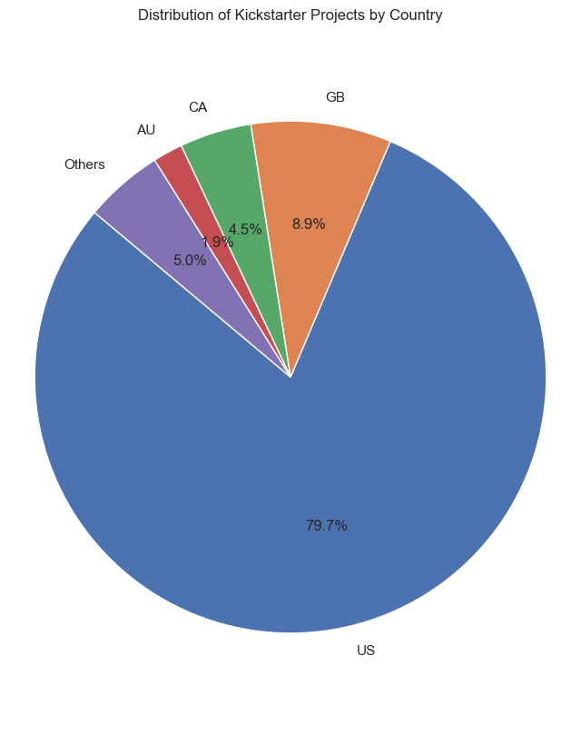

```python
# Creating a pie chart to visualize the distribution of projects by country
plt.figure(figsize=(8, 10))
plt.pie(final_project_by_country.values(), labels=final_project_by_country.keys(), autopct='%1.1f%%', startangle=140)
plt.title('Distribution of Kickstarter Projects by Country')
# Equal aspect ratio to ensure that pie is drawn as a circle.
plt.axis('equal')
```

Closing Points:

Overall, the pie chart illustrates that Kickstarter attracts a wide range of projects from different countries, but the US remains the dominant contributor in terms of project count.

## 2. Distribution of proportion of successful projects by country

## Code explanation to find count of successful projects by country

- An empty dictionary `success_by_country` is initialized to count the number of successful projects by country.
- An iterator `itr` is initialized to keep track of the current project.
- A `for` loop iterates through each country in the `country` list.
- Inside the loop, we check if the project state at the current iterator position is 'successful'.
- If the project is successful, it updates the count for that country in the `success_by_country` dictionary.
- After processing all projects, we print the count of successful projects by country along with the total projects for that country using`project_by_country` dictionary.

```python
# Initializing an empty dictionary to count successful projects by country
success_by_country = {}

# Initializing an iterator to keep track of the current project
itr = 0

# Iterating through each country in the 'country' list
for each_country in country:
    # Checking if the project state at the current iterator position is 'successful'
    if project_states[itr] == 'successful':
        # If the country is already in the 'success_by_country' dictionary, we increment the count
        if each_country in success_by_country:
            success_by_country[each_country] += 1
        # If the country is not in the dictionary, we add it with a count of 1
        else:
            success_by_country[each_country] = 1
    # Incrementing the iterator to move to the next project
    itr = itr + 1

# Printing the count of successful projects by country
for key, value in success_by_country.items():
    # Assuming you have a 'project_by_country' dictionary, you can print the total projects for that country
    print(f'Country - {key}: Success count - {value}: total projects - {project_by_country[key]}')
```

```
Country - US: Success count - 594: total projects - 3336
Country - SE: Success count - 8: total projects - 23
Country - GB: Success count - 56: total projects - 371
Country - FR: Success count - 5: total projects - 16
Country - CA: Success count - 10: total projects - 190
Country - AU: Success count - 8: total projects - 79
Country - DK: Success count - 2: total projects - 15
Country - NL: Success count - 2: total projects - 48
Country - CH: Success count - 1: total projects - 6
Country - ES: Success count - 1: total projects - 19
Country - DE: Success count - 3: total projects - 27
Country - BE: Success count - 1: total projects - 10
Country - IE: Success count - 1: total projects - 8
```

## Calculating the percentage of project successes for each country and storing it in a dictionary

```python
# Using a dictionary comprehension to calculate the proportion of project successes by country
proportion_of_success_projects_by_country = {key:(value/project_by_country[key])*100 for key,value in success_by_country.items()}

proportion_of_success_projects_by_country
```

```
{'US': 17.805755395683455,
 'SE': 34.78260869565217,
 'GB': 15.09433962264151,
 'FR': 31.25,
 'CA': 5.263157894736842,
 'AU': 10.126582278481013,
 'DK': 13.333333333333334,
 'NL': 4.166666666666666,
 'CH': 16.666666666666664,
 'ES': 5.263157894736842,
 'DE': 11.11111111111111,
 'BE': 10.0,
 'IE': 12.5}
```

## Created a bar chart below showing the distribution of proportion of successful projects by country

```
---------------  Bar graph using seaborn library  -------------------
```

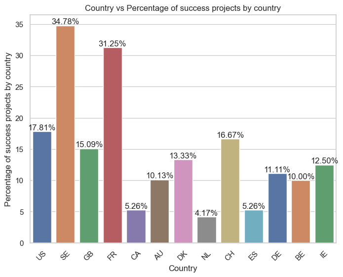

```python
# Displaying a bar chart showing a title, the countries, and percentages using seaborn
print('--------------- \033[1m Bar graph using seaborn library \033[0m -------------------')

# Data
countries = list(proportion_of_success_projects_by_country.keys())
proportions = list(proportion_of_success_projects_by_country.values())

# Create a bar chart using Seaborn
plt.figure(figsize=(8, 6))
sns.set(style="whitegrid")  # Setting style
axes = sns.barplot(x=countries, y=proportions, palette = 'deep')  # Creating the bar plot

# Adding percentage labels on top of the bars
for each_country, proportion in zip(countries, proportions):
    axes.text(countries.index(each_country), proportion, f'{proportion:.2f}%', ha='center', va='bottom', fontsize=12)

# Customize the plot
plt.title('Country vs Percentage of success projects by country')
plt.xlabel('Country')
plt.ylabel('Percentage of success projects by country')
# Rotating horizontal axis labels for better readability
plt.xticks(rotation=45)

# Showing the plot
plt.show()
```

## From the above bar chart visualization and calculated data we can infer the following:

- The US has the highest number of both successful projects and total projects, indicating a significant presence of Kickstarter projects in the US.
- Sweden (SE) has the highest proportion of successful projects (34.78%), suggesting a higher success rate compared to some other countries.
  - Another point to be noticed is though Sweden has got just 23 projects, the number of successful projects presented by them is 8 which is the reason for their high success rate compared to other countries.
- Netherlands (NL), Spain (ES) and Canada (CA) have relatively low success rates (4.17%, 5.26% and 5.26%, respectively), indicating that a substantial portion of projects in these countries did not meet their funding goals.
  - This also indicates that Kickstarter projects in these countries might face challenges in reaching their funding targets.

Closing Points:

The proportion of successful projects varies widely between countries, suggesting that various other factors like backers count, project category, goal amount set etc. may influence the success of Kickstarter campaigns in different regions.

"I pledge on my honor that I have not given nor received any unauthorized assistance on this assignment." -- Balaji Udayakumar